# Hertie Data Club - Session 1

Benjamin Gaiser

02 November 2016

### Introduction to R

#### R is an object-oriented programming language and environment for statistical computing and graphics.

#### R provides a wide variety of statistical and graphical techniques and is highly extensible (R-packages).

#### It is great with data management and for free!

#### R is the language, and RStudio is the integrated developer environment (IDE) that facilitates using R.

#### Public data is increasingly accesible and open and there are packages to directly download into your R environment.

- e.g. World Development Indicator, GovData Germany, data.gov.uk, New York City, etc.

#### There is a huge community that can help you with problems.

- If you ever have an error (and you will), Stackoverflow and R-Blogger will have the answer

### How does R look like?

#### R is divided in four quadrants

- The top left quadrant is the editor
- The bottom left quadrant is the console
- The top right quadrant is the global environment and history
- The bottom right quadrant is a multi-purpose quadrant that is mainly used for plots

### How does R work?

#### R is an object-oriented programme. The objects can be seen as R’s nouns:

- numeric (real numbers)

```r
numeric <- 10
numeric
```

```
## [1] 10
```

```r
numeric_vector <- c(1,2,3)
numeric_vector
```

```
## [1] 1 2 3
```

```r
class(numeric_vector)
```

```
## [1] "numeric"
```

- character

```r
character_vector <- c('Albania', 'Botswana', 'Cambodia')
character_vector
```

```
## [1] "Albania"  "Botswana" "Cambodia"
```

- integer (subset of numeric)
- logical

```r
logical_vector <- c(TRUE, FALSE, TRUE)
logical_vector
```

```
## [1]  TRUE FALSE  TRUE
```

```r
class(logical_vector)
```

```
## [1] "logical"
```

#### These objects are organized in three main ways

- Matrix

```r
matrix_combined <- cbind(numeric_vector, character_vector)
matrix_combined
```

```
##      numeric_vector character_vector
## [1,] "1"            "Albania"
## [2,] "2"            "Botswana"
## [3,] "3"            "Cambodia"
```

- Data Frames

```r
combined_df <- data.frame(numeric_vector, character_vector, stringsAsFactors = FALSE)
combined_df
```

```
##   numeric_vector character_vector
## 1              1          Albania
## 2              2         Botswana
## 3              3         Cambodia
```

- Lists

```r
test_list <- list(countries = character_vector, not_there = c(NA, NA),
                  more_numbers = 1:10)
test_list
```

```
## $countries
## [1] "Albania"  "Botswana" "Cambodia"
##
## $not_there
## [1] NA NA
##
## $more_numbers
##  [1]  1  2  3  4  5  6  7  8  9 10
```

### Statistics in R - What can it do?

```r
swiss <- as.data.frame(swiss)
library(Hmisc)
library(ggplot2)
```

#### Data Frame: Swiss Fertility and Socioeconomic Indicators (1888), R Data Set. Variables of interest:

- Independent Variable X: Catholic - % as opposed to Protestant
- Dependent Variable Y: Fertility - lg, common standardized fertility measure

#### What the data look like - Initial Descriptive Statistics

```r
summary(swiss)
```

```
##    Fertility      Agriculture     Examination      Education
##  Min.   :35.00   Min.   : 1.20   Min.   : 3.00   Min.   : 1.00
##  1st Qu.:64.70   1st Qu.:35.90   1st Qu.:12.00   1st Qu.: 6.00
##  Median :70.40   Median :54.10   Median :16.00   Median : 8.00
##  Mean   :70.14   Mean   :50.66   Mean   :16.49   Mean   :10.98
##  3rd Qu.:78.45   3rd Qu.:67.65   3rd Qu.:22.00   3rd Qu.:12.00
##  Max.   :92.50   Max.   :89.70   Max.   :37.00   Max.   :53.00
##     Catholic       Infant.Mortality
##  Min.   :  2.150   Min.   :10.80
##  1st Qu.:  5.195   1st Qu.:18.15
##  Median : 15.140   Median :20.00
##  Mean   : 41.144   Mean   :19.94
##  3rd Qu.: 93.125   3rd Qu.:21.70
##  Max.   :100.000   Max.   :26.60
```

### Hypothesis: Catholics have a higher fertility rate than Protestants.

#### First, we have a closer look at the initial descriptive statistics of our variables of interest.

```r
describe(swiss$Fertility)
```

```
## swiss$Fertility
##       n missing  unique    Info    Mean     .05     .10     .25     .50
##      47       0      46       1   70.14   47.58   56.24   64.70   70.40
##     .75     .90     .95
##   78.45   84.60   90.67
##
## lowest : 35.0 42.8 44.7 54.3 55.7, highest: 85.8 87.1 92.2 92.4 92.5
```

```r
describe(swiss$Catholic)
```

```
## swiss$Catholic
##       n missing  unique    Info    Mean     .05     .10     .25     .50
##      47       0      46       1   41.14   2.448   2.832   5.195  15.140
##     .75     .90     .95
##  93.125  99.000  99.614
##
## lowest :   2.15   2.27   2.40   2.56   2.82
## highest:  99.06  99.46  99.68  99.71 100.00
```

```r
var(swiss$Fertility)
```

```
## [1] 156.0425
```

```r
var(swiss$Catholic)
```

```
## [1] 1739.295
```

```r
sd(swiss$Fertility)
```

```
## [1] 12.4917
```

```r
sd(swiss$Catholic)
```

```
## [1] 41.70485
```

#### The variable ‘Catholic’ shows high variance and standard deviation for a continuous variable of between 0 and 100. Let’s plot the relationship in order to see how the relationship looks.

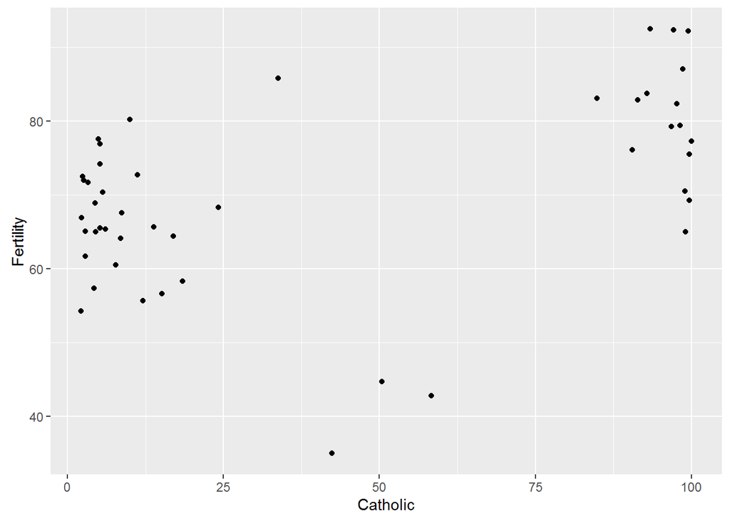

```r
ggplot(swiss, aes(Catholic, Fertility)) + geom_point()
```

#### Adding a line of best fit, we can see that this relationship is significant, explaining 20 % of the variance (R-value). Yet, the striking thing is the clear divide between mostly Protestant and mostly Catholic cantons, except of four “outliers in the middle”

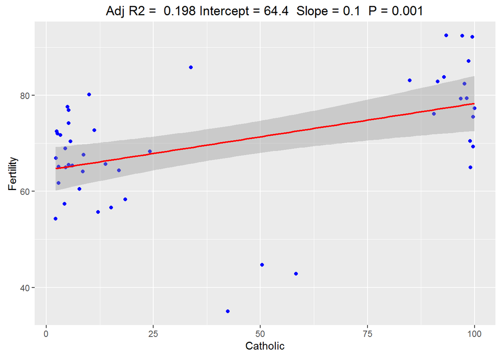

```r
ggplotRegSwiss <- function(fit){
  ggplot(swiss, aes(Catholic, Fertility)) +
    geom_point(colour = 'blue') +
    stat_smooth(method = 'lm', col = 'red', size=0.75) +
    labs(title = paste('Adj R2 = ',signif(summary(fit)$adj.r.squared, 3),
                       'Intercept =',signif(fit$coef[[1]],3 ),
                       ' Slope =',signif(fit$coef[[2]], 1),
                       ' P =',signif(summary(fit)$coef[2,4], 2)))
}
FitOfDataSwiss <- lm(Fertility ~ Catholic, data = swiss)
ggplotRegSwiss(FitOfDataSwiss)
```

### Which cantons are neither mostly Protestant nor mostly Catholic?

- Step 1: Creating a factor variable with four different groups.

```r
swiss$CatholicCat <- cut(swiss$Catholic, seq(0, 100, 25))
```

- Step 2: Changing the factor variable into a character variable in order to rename the rownames.

```r
swiss$CatholicCat <- as.character(swiss$CatholicCat)
```

- Step 3: Renaming the rownames.

```r
swiss$CatholicCat[swiss$CatholicCat=='(0,25]'] <- 'Protestant'
swiss$CatholicCat[swiss$CatholicCat=='(25,50]'] <- 'Protestant to Catholic'
swiss$CatholicCat[swiss$CatholicCat=='(50,75]'] <- 'Catholic to Protestant'
swiss$CatholicCat[swiss$CatholicCat=='(75,100]'] <- 'Catholic'
```

- Step 4: Finding the cantons which are ‘Protestant to Catholic’ and ‘Catholic to Protestant’.

```r
which(grepl('Protestant to Catholic', swiss$CatholicCat)) # 4 and 45
```

```
## [1]  4 45
```

```r
which(grepl('Catholic to Protestant', swiss$CatholicCat)) # 46 and 47
```

```
## [1] 46 47
```

- Step 5: Searching the names.

```r
swiss[c(4,45:47),]
```

```
##              Fertility Agriculture Examination Education Catholic
## Moutier           85.8        36.5          12         7    33.77
## V. De Geneve      35.0         1.2          37        53    42.34
## Rive Droite       44.7        46.6          16        29    50.43
## Rive Gauche       42.8        27.7          22        29    58.33
##              Infant.Mortality            CatholicCat
## Moutier                  20.3 Protestant to Catholic
## V. De Geneve             18.0 Protestant to Catholic
## Rive Droite              18.2 Catholic to Protestant
## Rive Gauche              19.3 Catholic to Protestant
```

#### Moutier, V. De Geneve, Rive Droite and Rive Gauce are the only cantons where there is at least a third of the population that does not belong to the majority religion.